# Hackathon - Raport z analizy danych

Patryk Marek, Paweł Woźniak, Dominika Wójcik, Michał Koziński

6/4/2022

# Cel badania

Celem naszego badania jest znalezienie i przeanalizowanie czynników wpływających na ceny mieszkań w oparciu o dane Grupy OLX z portalu Otodom.pl oraz wyszukanie najczęściej pojawiających się schematów w wystawianych ofertach. Końcowym etapem naszego raportu jest wykonanie predykcji cen mieszkań w oparicu o dostarczone dane.

# Opis zbioru badawczego

W skład zbioru badawczego wchodzą cztery pliki:

- Cities - nazwy miast z położeniem geograficznym;
- Districts - nazwy dzielnic z położeniem geograficznym;
- Train - dane dotyczące ogłoszeń;
- Test - dane dotyczące ogłoszeń bez kolumny price (predykcja).

W zbiorze “Train” kluczową kolumną jest “params” zawierającą wszystkie uzupełnione opcje podczas wystawiania oferty na portalu. Ze względu na strukturę tej kolumny koniecznne było wycięcie z niej wszystkich parametrów i wpisanie ich w nowe pola dla każdego wiersza.

Z całej populacji wybieramy losowo próbkę 100 tysięcy obserwacji.

Zbiór danych zawiera kilka wartości znacząco odstająco od reszty co widać na poniższym wykresie ramka-wąsy. Usuniemy je w celu zoptymalizowania dalszych obliczeń.

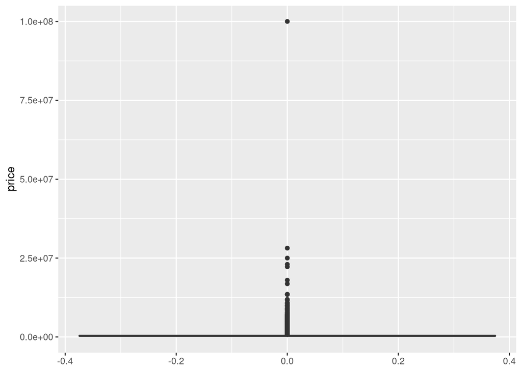

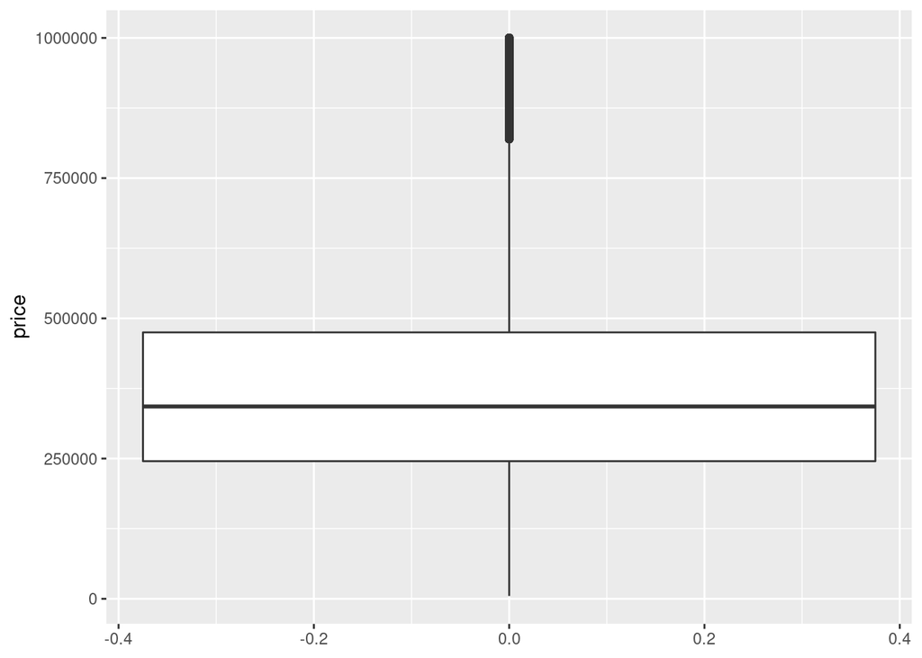

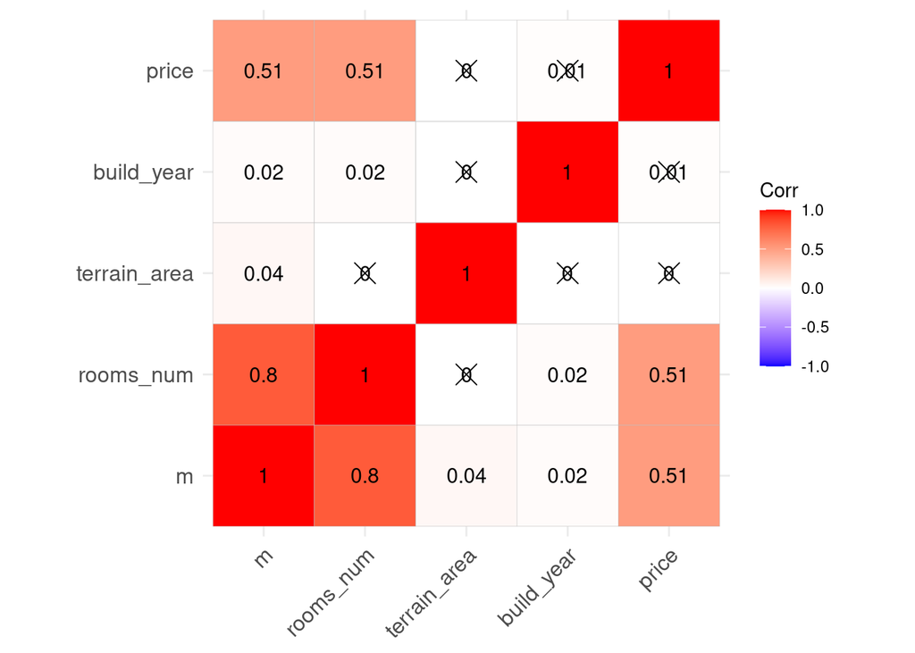

Ze zmiennych numerycznych odrzucamy zmienną “build_year” ze względu na brak istotnej korelacji ze zmienną “price” oraz zmienną “terrain_area” ponieważ jest zbyt słabo skorelowana.

Pozostałe zmienne będziemy testowali w naszym modelu.

### Dane numeryczne

Podstawowe statystyki opisowe dla zmiennych numerycznych:

|  | price | rooms_num | m |
| --- | --- | --- | --- |
| Min. | 5000 | 1.00 | 1.00 |
| 1st Qu. | 245358 | 2.00 | 45.99 |
| Median | 342864 | 3.00 | 58.67 |
| Mean | 380607 | 2.99 | 77.55 |
| 3rd Qu. | 475000 | 4.00 | 85.00 |
| Max. | 999999 | 10.00 | 780.00 |
| NA’s | 0 | 204 | 0 |

### Dane typu kategorycznego

Dla zmiennych kategorycznych prezentujemy ich możliwe poziomy, oraz liczby wystąpień każdego poziomu:

|  | category | is_business | market | is_bungalow | location | building_type | construction_status |
| --- | --- | --- | --- | --- | --- | --- | --- |
|  | Dom na sprzedaż :18699 | 0: 9327 | secondary:64346 | 0 :15409 | city : 2538 | block :37908 | ready_to_use :29593 |
|  | Mieszkanie na sprzedaż:76039 | 1:85411 | primary :30392 | 1 : 3290 | country : 1423 | apartment :12809 | to_renovation : 6114 |
|  |  |  |  | NA’s:76039 | suburban: 2094 | detached :10006 | to_completion :18437 |
|  |  |  |  |  | NA’s :88683 | tenement : 7611 | unfinished_close: 600 |
|  |  |  |  |  |  | semi_detached: 3666 | unfinished_open : 212 |
|  |  |  |  |  |  | (Other) : 4025 | NA’s :39782 |
|  |  |  |  |  |  | NA’s :18713 |  |

Te same dane w zestawieniu graficznym:

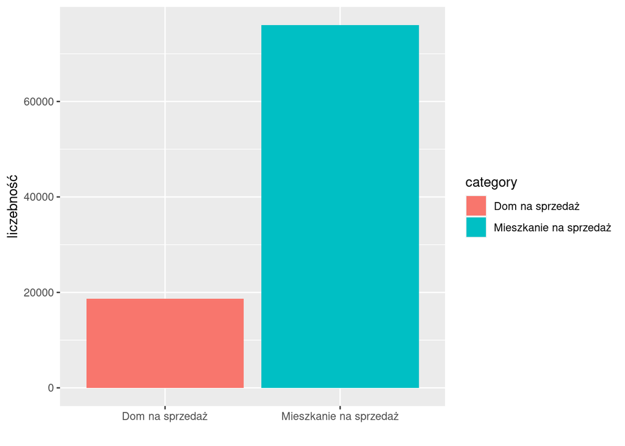

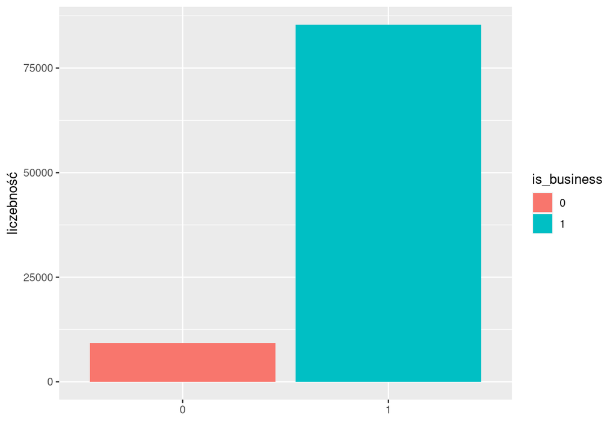

# Regresja wieloraka - budowanie modelu

```
## Analysis of Variance Table
##
## Model 1: price ~ 1
## Model 2: price ~ m
##   Res.Df        RSS Df  Sum of Sq      F    Pr(>F)
## 1   4999 1.8109e+14
## 2   4998 1.2260e+14  1 5.8496e+13 2384.7 < 2.2e-16 ***
## ---
## Signif. codes:  0 '***' 0.001 '**' 0.01 '*' 0.05 '.' 0.1 ' ' 1
```

```
##
## Call:
## lm(formula = price ~ m, data = pod_train)
##
## Residuals:
##     Min      1Q  Median      3Q     Max
## -852465  -98490  -24956   75149  609801
##
## Coefficients:
##              Estimate Std. Error t value Pr(>|t|)
## (Intercept) 228485.43    4111.73   55.57   <2e-16 ***
## m             2554.97      52.32   48.83   <2e-16 ***
## ---
## Signif. codes:  0 '***' 0.001 '**' 0.01 '*' 0.05 '.' 0.1 ' ' 1
##
## Residual standard error: 156600 on 4998 degrees of freedom
## Multiple R-squared:  0.323,  Adjusted R-squared:  0.3229
## F-statistic:  2385 on 1 and 4998 DF,  p-value: < 2.2e-16
```

```
## Analysis of Variance Table
##
## Model 1: price ~ m
## Model 2: price ~ m + rooms_num
##   Res.Df        RSS Df  Sum of Sq      F    Pr(>F)
## 1   4998 1.2260e+14
## 2   4997 1.1893e+14  1 3.6669e+12 154.07 < 2.2e-16 ***
## ---
## Signif. codes:  0 '***' 0.001 '**' 0.01 '*' 0.05 '.' 0.1 ' ' 1
```

```
##
## Call:
## lm(formula = price ~ m + rooms_num, data = pod_train)
##
## Residuals:
##     Min      1Q  Median      3Q     Max
## -682274  -98002  -22845   72466  633521
##
## Coefficients:
##              Estimate Std. Error t value Pr(>|t|)
## (Intercept) 177825.79    5749.89   30.93   <2e-16 ***
## m             1713.54      85.15   20.12   <2e-16 ***
## rooms_num    38451.49    3097.80   12.41   <2e-16 ***
## ---
## Signif. codes:  0 '***' 0.001 '**' 0.01 '*' 0.05 '.' 0.1 ' ' 1
##
## Residual standard error: 154300 on 4997 degrees of freedom
## Multiple R-squared:  0.3433, Adjusted R-squared:  0.343
## F-statistic:  1306 on 2 and 4997 DF,  p-value: < 2.2e-16
```

```
## Analysis of Variance Table
##
## Model 1: price ~ m + rooms_num
## Model 2: price ~ m + rooms_num + category
##   Res.Df        RSS Df  Sum of Sq      F    Pr(>F)
## 1   4997 1.1893e+14
## 2   4996 1.1545e+14  1 3.4765e+12 150.44 < 2.2e-16 ***
## ---
## Signif. codes:  0 '***' 0.001 '**' 0.01 '*' 0.05 '.' 0.1 ' ' 1
```

```
##
## Call:
## lm(formula = price ~ m + rooms_num + category, data = pod_train)
##
## Residuals:
##     Min      1Q  Median      3Q     Max
## -769876  -96218  -19936   76042  624630
##
## Coefficients:
##                                Estimate Std. Error t value Pr(>|t|)
## (Intercept)                      5668.0    15136.5   0.374    0.708
## m                                2465.7      103.9  23.725   <2e-16 ***
## rooms_num                       36299.2     3057.5  11.872   <2e-16 ***
## categoryMieszkanie na sprzedaż 140689.6    11470.5  12.265   <2e-16 ***
## ---
## Signif. codes:  0 '***' 0.001 '**' 0.01 '*' 0.05 '.' 0.1 ' ' 1
##
## Residual standard error: 152000 on 4996 degrees of freedom
## Multiple R-squared:  0.3625, Adjusted R-squared:  0.3621
## F-statistic: 946.8 on 3 and 4996 DF,  p-value: < 2.2e-16
```

```
##
## Call:
## lm(formula = price ~ m + rooms_num + category + is_business,
##     data = pod_train)
##
## Residuals:
##     Min      1Q  Median      3Q     Max
## -769895  -96302  -19752   75997  624927
##
## Coefficients:
##                                Estimate Std. Error t value Pr(>|t|)
## (Intercept)                        7046      15746   0.448    0.655
## m                                  2466        104  23.724   <2e-16 ***
## rooms_num                         36336       3060  11.875   <2e-16 ***
## categoryMieszkanie na sprzedaż   140865      11485  12.265   <2e-16 ***
## is_business1                      -1958       6153  -0.318    0.750
## ---
## Signif. codes:  0 '***' 0.001 '**' 0.01 '*' 0.05 '.' 0.1 ' ' 1
##
## Residual standard error: 152000 on 4995 degrees of freedom
## Multiple R-squared:  0.3625, Adjusted R-squared:  0.362
## F-statistic:   710 on 4 and 4995 DF,  p-value: < 2.2e-16
```

Zmienna is_bussines nie jest istotna statystycznie.

```
##
## Call:
## lm(formula = price ~ m + rooms_num + category + market, data = pod_train)
##
## Residuals:
##     Min      1Q  Median      3Q     Max
## -776054  -99512  -20768   75856  630343
##
## Coefficients:
##                                Estimate Std. Error t value Pr(>|t|)
## (Intercept)                     -2843.5    15222.0  -0.187    0.852
## m                                2522.6      104.5  24.145  < 2e-16 ***
## rooms_num                       34863.0     3067.8  11.364  < 2e-16 ***
## categoryMieszkanie na sprzedaż 142980.3    11459.0  12.478  < 2e-16 ***
## marketprimary                   21252.3     4668.4   4.552 5.43e-06 ***
## ---
## Signif. codes:  0 '***' 0.001 '**' 0.01 '*' 0.05 '.' 0.1 ' ' 1
##
## Residual standard error: 151700 on 4995 degrees of freedom
## Multiple R-squared:  0.3651, Adjusted R-squared:  0.3646
## F-statistic: 718.1 on 4 and 4995 DF,  p-value: < 2.2e-16
```

```
##
## Call:
## lm(formula = price ~ m + rooms_num + category + building_type,
##     data = pod_train)
##
## Residuals:
##     Min      1Q  Median      3Q     Max
## -768742  -95779  -18145   73543  631302
##
## Coefficients:
##                                 Estimate Std. Error t value Pr(>|t|)
## (Intercept)                      66573.4    17419.8   3.822 0.000134 ***
## m                                 2461.3      102.2  24.082  < 2e-16 ***
## rooms_num                        34419.8     2973.0  11.578  < 2e-16 ***
## categoryMieszkanie na sprzedaż  118618.4    28046.0   4.229 2.38e-05 ***
## building_typetenement           -41488.2    30599.2  -1.356 0.175205
## building_typehouse             -111012.4    37706.2  -2.944 0.003253 **
## building_typeblock              -61182.8    30229.4  -2.024 0.043028 *
## building_typedetached           -86158.1    16353.7  -5.268 1.43e-07 ***
## building_typeapartment           43173.1    30403.5   1.420 0.155669
## building_typeribbon             -50552.8    19014.8  -2.659 0.007871 **
## building_typeinfill              67295.5    57133.1   1.178 0.238904
## building_typeloft               -66377.1   107384.1  -0.618 0.536520
## ---
## Signif. codes:  0 '***' 0.001 '**' 0.01 '*' 0.05 '.' 0.1 ' ' 1
##
## Residual standard error: 145700 on 4988 degrees of freedom
## Multiple R-squared:  0.4153, Adjusted R-squared:  0.414
## F-statistic: 322.1 on 11 and 4988 DF,  p-value: < 2.2e-16
```

```
##
## Call:
## lm(formula = price ~ m + rooms_num + category + city_name, data = pod_train)
##
## Residuals:
##     Min      1Q  Median      3Q     Max
## -757711  -62004  -12794   44692  554138
##
## Coefficients:
##                                  Estimate Std. Error t value Pr(>|t|)
## (Intercept)                     -99281.83   27799.46  -3.571 0.000359 ***
## m                                 2503.77      80.97  30.923  < 2e-16 ***
## rooms_num                        36473.91    2373.79  15.365  < 2e-16 ***
## categoryMieszkanie na sprzedaż   70218.56    9068.16   7.743 1.17e-14 ***
## city_nameBiałystok               76449.31   28510.31   2.681 0.007355 **
## city_nameBielsko-Biała           90368.17   31916.47   2.831 0.004653 **
## city_nameBoguszów-Gorce        -111990.53  118525.15  -0.945 0.344773
## city_nameBydgoszcz               53431.16   27335.75   1.955 0.050684 .
## city_nameBytom                  -53651.62   31170.25  -1.721 0.085270 .
## city_nameChełm                  -19180.15   85570.26  -0.224 0.822654
## city_nameChorzów                -44001.85   41859.88  -1.051 0.293232
## city_nameCzeladź                -20524.01   71409.11  -0.287 0.773807
## city_nameCzęstochowa             20387.75   28665.89   0.711 0.476982
## city_nameDąbrowa Górnicza        19412.19   30087.59   0.645 0.518835
## city_nameGdańsk                 221366.97   26167.39   8.460  < 2e-16 ***
## city_nameGdynia                 228990.24   28197.49   8.121 5.80e-16 ***
## city_nameGliwice                 55661.36   30674.01   1.815 0.069645 .
## city_nameGłogów                   7214.98   63087.68   0.114 0.908954
## city_nameGniezno                152084.03   85597.27   1.777 0.075673 .
## city_nameGorzów Wielkopolski    -31728.76   33935.47  -0.935 0.349848
## city_nameGrodzisk Mazowiecki     98213.59   63123.20   1.556 0.119796
## city_nameGrudziądz                7471.99   41887.77   0.178 0.858431
## city_nameInowrocław              60147.45   71376.88   0.843 0.399452
## city_nameJastrzębie-Zdrój       -51139.92   50469.83  -1.013 0.310978
## city_nameJaworzno               -28016.28   50479.93  -0.555 0.578921
## city_nameJelenia Góra            -6862.78   34906.77  -0.197 0.844146
## city_nameJózefów                 -7165.68  118724.11  -0.060 0.951875
## city_nameKalisz                  48468.42   85628.13   0.566 0.571397
## city_nameKatowice                88295.49   26663.23   3.312 0.000935 ***
## city_nameKędzierzyn-Koźle      -188269.35   71425.42  -2.636 0.008418 **
```

[output cut: 56 more lines]

```
## city_nameWieliczka               90303.52   71382.31   1.265 0.205907
## city_nameWłocławek              -19584.91   43086.36  -0.455 0.649453
## city_nameWrocław                168352.19   25713.51   6.547 6.46e-11 ***
## city_nameWrząsowice             253309.54  118446.56   2.139 0.032518 *
## city_nameZabrze                 -27652.44   33403.07  -0.828 0.407801
## city_nameZakopane               411275.49   85644.51   4.802 1.62e-06 ***
## city_nameZielona Góra            75167.55   48052.34   1.564 0.117815
## city_nameŻory                   -23040.63   39899.90  -0.577 0.563655
## city_nameŻyrardów                 8942.16  118355.14   0.076 0.939777
## ---
## Signif. codes:  0 '***' 0.001 '**' 0.01 '*' 0.05 '.' 0.1 ' ' 1
##
## Residual standard error: 115600 on 4905 degrees of freedom
## Multiple R-squared:  0.6379, Adjusted R-squared:  0.631
## F-statistic: 91.94 on 94 and 4905 DF,  p-value: < 2.2e-16
```

```
##
## Call:
## lm(formula = price ~ m + rooms_num + category + city_name + construction_status,
##     data = pod_train)
##
## Residuals:
##     Min      1Q  Median      3Q     Max
## -703184  -61562  -12619   45872  542103
##
## Coefficients:
##                                       Estimate Std. Error t value Pr(>|t|)
## (Intercept)                          -75542.74   27482.85  -2.749 0.006005 **
## m                                      2431.06      80.37  30.247  < 2e-16 ***
## rooms_num                             37338.86    2348.76  15.897  < 2e-16 ***
## categoryMieszkanie na sprzedaż        62421.20    9172.22   6.805 1.13e-11 ***
## city_nameBiałystok                    82853.05   28062.54   2.952 0.003168 **
## city_nameBielsko-Biała                85815.75   31417.98   2.731 0.006329 **
## city_nameBoguszów-Gorce              -67309.50  116720.73  -0.577 0.564188
## city_nameBydgoszcz                    57339.71   26902.89   2.131 0.033109 *
## city_nameBytom                       -48895.79   30713.08  -1.592 0.111445
## city_nameChełm                        -1435.18   84219.91  -0.017 0.986405
## city_nameChorzów                     -38966.92   41193.56  -0.946 0.344222
## city_nameCzeladź                     -36817.74   70277.98  -0.524 0.600381
## city_nameCzęstochowa                  20731.54   28212.27   0.735 0.462471
## city_nameDąbrowa Górnicza             24728.61   29649.37   0.834 0.404302
## city_nameGdańsk                      222493.64   25759.56   8.637  < 2e-16 ***
## city_nameGdynia                      226245.45   27747.81   8.154 4.45e-16 ***
## city_nameGliwice                      60913.49   30189.55   2.018 0.043677 *
## city_nameGłogów                       -7069.65   62088.99  -0.114 0.909351
## city_nameGniezno                     135642.42   84238.73   1.610 0.107415
## city_nameGorzów Wielkopolski         -35626.15   33394.68  -1.067 0.286105
## city_nameGrodzisk Mazowiecki         102184.11   62141.83   1.644 0.100164
## city_nameGrudziądz                    16599.72   41411.13   0.401 0.688547
## city_nameInowrocław                   45662.05   70243.78   0.650 0.515690
## city_nameJastrzębie-Zdrój            -38524.73   49686.33  -0.775 0.438165
## city_nameJaworzno                    -19705.41   49676.86  -0.397 0.691627
## city_nameJelenia Góra                 -2529.92   34401.36  -0.074 0.941378
## city_nameJózefów                     -15148.05  116826.48  -0.130 0.896839
## city_nameKalisz                       31664.02   84269.21   0.376 0.707120
## city_nameKatowice                     95832.68   26265.05   3.649 0.000266 ***
```

[output cut: 61 more lines]

```
## city_nameZabrze                      -11311.33   33229.09  -0.340 0.733567
## city_nameZakopane                    397631.46   84279.88   4.718 2.45e-06 ***
## city_nameZielona Góra                 77077.68   47309.30   1.629 0.103329
## city_nameŻory                        -27575.94   39262.87  -0.702 0.482500
## city_nameŻyrardów                     -5385.06  116465.16  -0.046 0.963123
## construction_statusto_renovation     -64609.46    5388.24 -11.991  < 2e-16 ***
## construction_statusto_completion     -27180.88    3689.94  -7.366 2.05e-13 ***
## construction_statusunfinished_close  -36315.06   22889.22  -1.587 0.112677
## construction_statusunfinished_open   -51312.56   44872.82  -1.144 0.252882
## ---
## Signif. codes:  0 '***' 0.001 '**' 0.01 '*' 0.05 '.' 0.1 ' ' 1
##
## Residual standard error: 113800 on 4901 degrees of freedom
## Multiple R-squared:  0.6497, Adjusted R-squared:  0.6427
## F-statistic: 92.76 on 98 and 4901 DF,  p-value: < 2.2e-16
```

```
##
## Call:
## lm(formula = price ~ m + rooms_num + category + city_name, data = pod_train)
##
## Residuals:
##     Min      1Q  Median      3Q     Max
## -757711  -62004  -12794   44692  554138
##
## Coefficients:
##                                  Estimate Std. Error t value Pr(>|t|)
## (Intercept)                     -99281.83   27799.46  -3.571 0.000359 ***
## m                                 2503.77      80.97  30.923  < 2e-16 ***
## rooms_num                        36473.91    2373.79  15.365  < 2e-16 ***
## categoryMieszkanie na sprzedaż   70218.56    9068.16   7.743 1.17e-14 ***
## city_nameBiałystok               76449.31   28510.31   2.681 0.007355 **
## city_nameBielsko-Biała           90368.17   31916.47   2.831 0.004653 **
## city_nameBoguszów-Gorce        -111990.53  118525.15  -0.945 0.344773
## city_nameBydgoszcz               53431.16   27335.75   1.955 0.050684 .
## city_nameBytom                  -53651.62   31170.25  -1.721 0.085270 .
## city_nameChełm                  -19180.15   85570.26  -0.224 0.822654
## city_nameChorzów                -44001.85   41859.88  -1.051 0.293232
## city_nameCzeladź                -20524.01   71409.11  -0.287 0.773807
## city_nameCzęstochowa             20387.75   28665.89   0.711 0.476982
## city_nameDąbrowa Górnicza        19412.19   30087.59   0.645 0.518835
## city_nameGdańsk                 221366.97   26167.39   8.460  < 2e-16 ***
## city_nameGdynia                 228990.24   28197.49   8.121 5.80e-16 ***
## city_nameGliwice                 55661.36   30674.01   1.815 0.069645 .
## city_nameGłogów                   7214.98   63087.68   0.114 0.908954
## city_nameGniezno                152084.03   85597.27   1.777 0.075673 .
## city_nameGorzów Wielkopolski    -31728.76   33935.47  -0.935 0.349848
## city_nameGrodzisk Mazowiecki     98213.59   63123.20   1.556 0.119796
## city_nameGrudziądz                7471.99   41887.77   0.178 0.858431
## city_nameInowrocław              60147.45   71376.88   0.843 0.399452
## city_nameJastrzębie-Zdrój       -51139.92   50469.83  -1.013 0.310978
## city_nameJaworzno               -28016.28   50479.93  -0.555 0.578921
## city_nameJelenia Góra            -6862.78   34906.77  -0.197 0.844146
## city_nameJózefów                 -7165.68  118724.11  -0.060 0.951875
## city_nameKalisz                  48468.42   85628.13   0.566 0.571397
## city_nameKatowice                88295.49   26663.23   3.312 0.000935 ***
## city_nameKędzierzyn-Koźle      -188269.35   71425.42  -2.636 0.008418 **
```

[output cut: 56 more lines]

```
## city_nameWieliczka               90303.52   71382.31   1.265 0.205907
## city_nameWłocławek              -19584.91   43086.36  -0.455 0.649453
## city_nameWrocław                168352.19   25713.51   6.547 6.46e-11 ***
## city_nameWrząsowice             253309.54  118446.56   2.139 0.032518 *
## city_nameZabrze                 -27652.44   33403.07  -0.828 0.407801
## city_nameZakopane               411275.49   85644.51   4.802 1.62e-06 ***
## city_nameZielona Góra            75167.55   48052.34   1.564 0.117815
## city_nameŻory                   -23040.63   39899.90  -0.577 0.563655
## city_nameŻyrardów                 8942.16  118355.14   0.076 0.939777
## ---
## Signif. codes:  0 '***' 0.001 '**' 0.01 '*' 0.05 '.' 0.1 ' ' 1
##
## Residual standard error: 115600 on 4905 degrees of freedom
## Multiple R-squared:  0.6379, Adjusted R-squared:  0.631
## F-statistic: 91.94 on 94 and 4905 DF,  p-value: < 2.2e-16
```

```
##
## Call:
## lm(formula = price ~ m + rooms_num + category, data = pod_train)
##
## Residuals:
##     Min      1Q  Median      3Q     Max
## -769876  -96218  -19936   76042  624630
##
## Coefficients:
##                                Estimate Std. Error t value Pr(>|t|)
## (Intercept)                      5668.0    15136.5   0.374    0.708
## m                                2465.7      103.9  23.725   <2e-16 ***
## rooms_num                       36299.2     3057.5  11.872   <2e-16 ***
## categoryMieszkanie na sprzedaż 140689.6    11470.5  12.265   <2e-16 ***
## ---
## Signif. codes:  0 '***' 0.001 '**' 0.01 '*' 0.05 '.' 0.1 ' ' 1
##
## Residual standard error: 152000 on 4996 degrees of freedom
## Multiple R-squared:  0.3625, Adjusted R-squared:  0.3621
## F-statistic: 946.8 on 3 and 4996 DF,  p-value: < 2.2e-16
```

Najlepszy model znaleziony metodą wstępującą:
$$price \sim m + rooms\_num + category$$

```
## [1] 0.3822833
```

```
##
##  Shapiro-Wilk normality test
##
## data:  mod6$residuals
## W = 0.96178, p-value < 2.2e-16
```

```
##
##  Lilliefors (Kolmogorov-Smirnov) normality test
##
## data:  mod6$residuals
## D = 0.07185, p-value < 2.2e-16
```

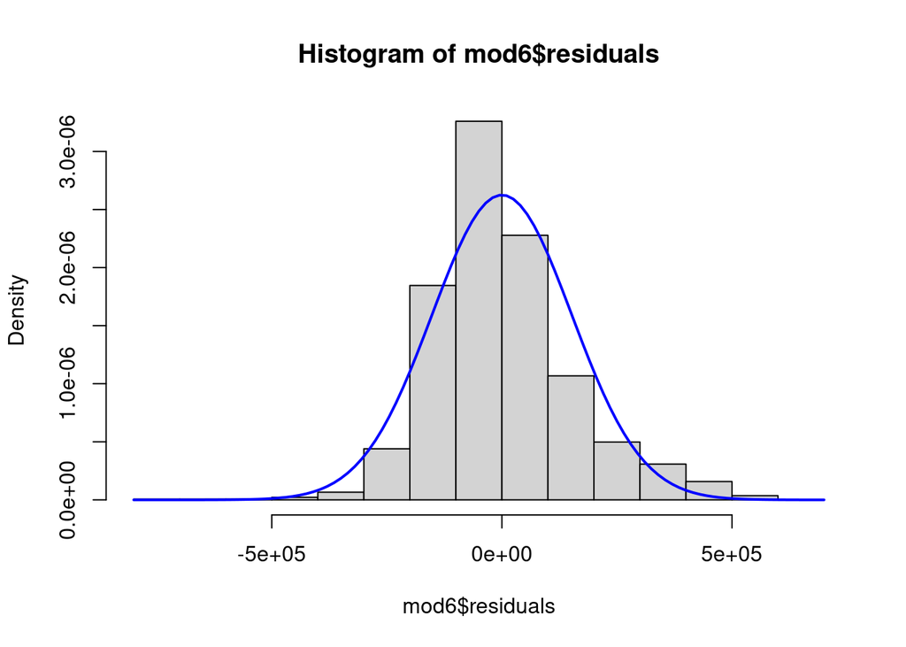

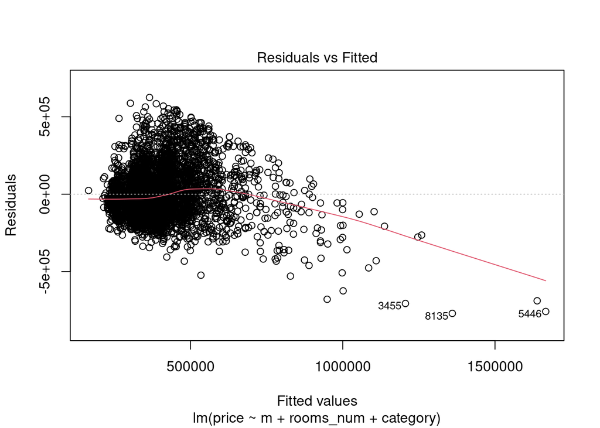

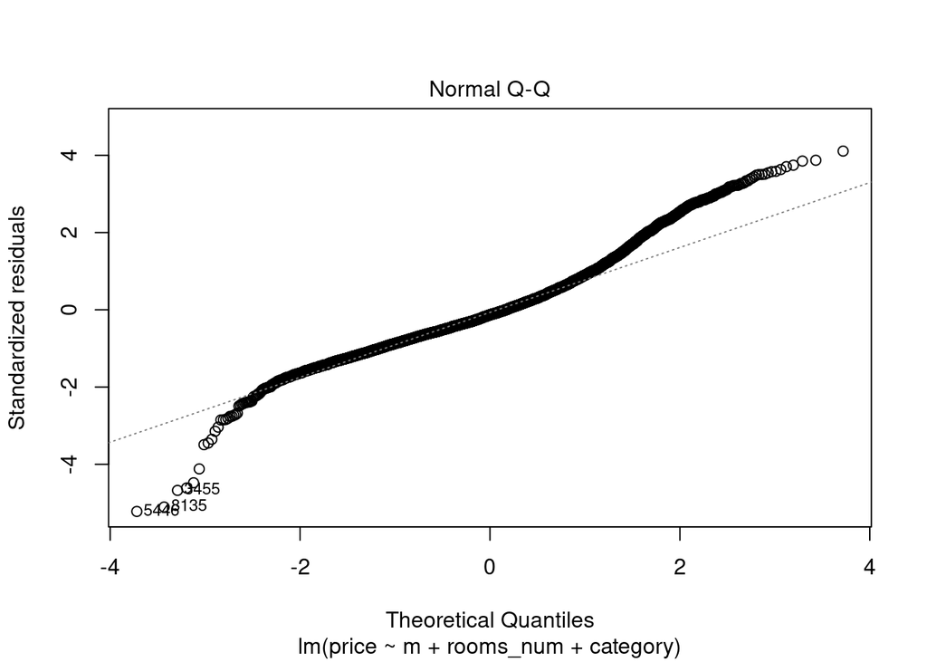

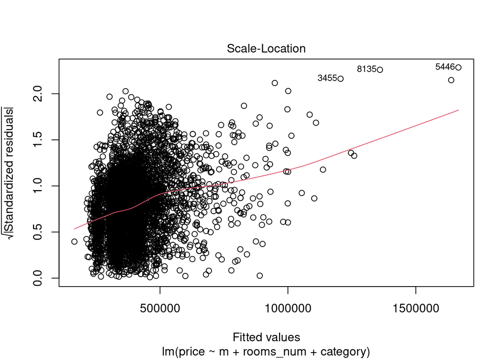

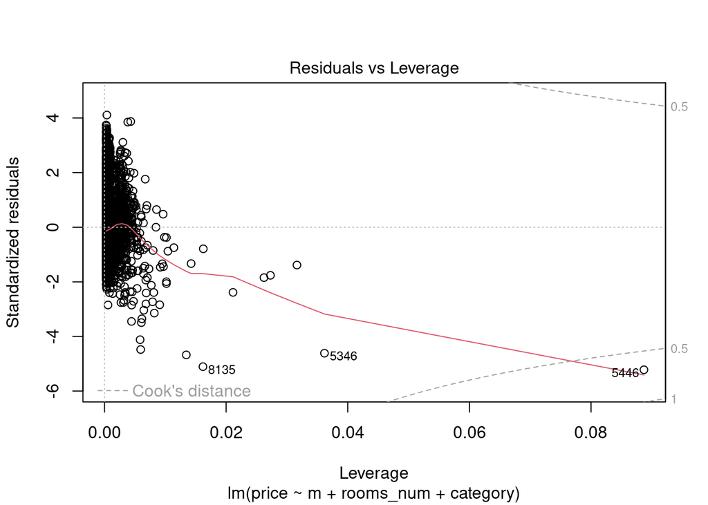

```
##
##  Rainbow test
##
## data:  mod6
## Rain = 1.5867, df1 = 2500, df2 = 2496, p-value < 2.2e-16
```

# Predykcja z wykorzysaniem lasu losowego

| mtry | trees | min_n |
| --- | --- | --- |
| 18 | 1,948 | 21 |
| 33 | 1,323 | 31 |
| 13 | 1,071 | 20 |
| 1 | 345 | 2 |
| 26 | 1,786 | 33 |
| 10 | 180 | 37 |
| 5 | 1,438 | 14 |
| 24 | 806 | 9 |
| 19 | 720 | 10 |
| 29 | 519 | 28 |

| mtry | trees | min_n | .metric | .estimator | mean | n | std_err | .config |
| --- | --- | --- | --- | --- | --- | --- | --- | --- |
| 18 | 1,948 | 21 | mae | standard | 122,965.8087545 | 5 | 2,179.85604132 | Preprocessor1_Model01 |
| 18 | 1,948 | 21 | rmse | standard | 163,659.4333089 | 5 | 4,961.82373749 | Preprocessor1_Model01 |
| 18 | 1,948 | 21 | rsq | standard | 0.2998362 | 5 | 0.02584644 | Preprocessor1_Model01 |
| 33 | 1,323 | 31 | mae | standard | 120,929.6138257 | 5 | 2,613.95007706 | Preprocessor1_Model02 |
| 33 | 1,323 | 31 | rmse | standard | 161,019.3090850 | 5 | 5,580.95125267 | Preprocessor1_Model02 |
| 33 | 1,323 | 31 | rsq | standard | 0.3175588 | 5 | 0.02902539 | Preprocessor1_Model02 |
| 13 | 1,071 | 20 | mae | standard | 123,392.3263079 | 5 | 1,980.60955540 | Preprocessor1_Model03 |
| 13 | 1,071 | 20 | rmse | standard | 164,224.3617219 | 5 | 4,822.61310106 | Preprocessor1_Model03 |
| 13 | 1,071 | 20 | rsq | standard | 0.2962858 | 5 | 0.02597249 | Preprocessor1_Model03 |
| 1 | 345 | 2 | mae | standard | 120,307.2342181 | 5 | 2,210.88284669 | Preprocessor1_Model04 |
| 1 | 345 | 2 | rmse | standard | 159,895.4200589 | 5 | 4,706.02275889 | Preprocessor1_Model04 |
| 1 | 345 | 2 | rsq | standard | 0.3174437 | 5 | 0.02842500 | Preprocessor1_Model04 |
| 26 | 1,786 | 33 | mae | standard | 120,593.4942180 | 5 | 2,747.07878333 | Preprocessor1_Model05 |
| 26 | 1,786 | 33 | rmse | standard | 160,516.8099790 | 5 | 5,740.85568961 | Preprocessor1_Model05 |
| 26 | 1,786 | 33 | rsq | standard | 0.3216086 | 5 | 0.02974027 | Preprocessor1_Model05 |
| 10 | 180 | 37 | mae | standard | 120,229.5792423 | 5 | 2,889.13691974 | Preprocessor1_Model06 |
| 10 | 180 | 37 | rmse | standard | 159,652.2658712 | 5 | 5,848.75486079 | Preprocessor1_Model06 |
| 10 | 180 | 37 | rsq | standard | 0.3273024 | 5 | 0.02908806 | Preprocessor1_Model06 |
| 5 | 1,438 | 14 | mae | standard | 125,510.0090426 | 5 | 1,673.74866859 | Preprocessor1_Model07 |
| 5 | 1,438 | 14 | rmse | standard | 167,042.9676509 | 5 | 4,340.17212818 | Preprocessor1_Model07 |
| 5 | 1,438 | 14 | rsq | standard | 0.2805593 | 5 | 0.02439277 | Preprocessor1_Model07 |
| 24 | 806 | 9 | mae | standard | 128,144.3782222 | 5 | 1,258.00899356 | Preprocessor1_Model08 |
| 24 | 806 | 9 | rmse | standard | 170,867.6640864 | 5 | 3,340.87017224 | Preprocessor1_Model08 |
| 24 | 806 | 9 | rsq | standard | 0.2602185 | 5 | 0.02327964 | Preprocessor1_Model08 |
| 19 | 720 | 10 | mae | standard | 127,816.1517244 | 5 | 1,387.95929392 | Preprocessor1_Model09 |
| 19 | 720 | 10 | rmse | standard | 170,449.0495026 | 5 | 3,578.00328747 | Preprocessor1_Model09 |
| 19 | 720 | 10 | rsq | standard | 0.2632445 | 5 | 0.02331856 | Preprocessor1_Model09 |
| 29 | 519 | 28 | mae | standard | 121,376.5340580 | 5 | 2,349.89238816 | Preprocessor1_Model10 |
| 29 | 519 | 28 | rmse | standard | 161,580.9135358 | 5 | 5,220.26269937 | Preprocessor1_Model10 |
| 29 | 519 | 28 | rsq | standard | 0.3135119 | 5 | 0.02733521 | Preprocessor1_Model10 |

```
## # A tibble: 5 × 9
##    mtry trees min_n .metric .estimator  mean     n std_err .config
##   <int> <int> <int> <chr>   <chr>      <dbl> <int>   <dbl> <chr>
## 1    10   180    37 rsq     standard   0.327     5  0.0291 Preprocessor1_Model06
## 2    26  1786    33 rsq     standard   0.322     5  0.0297 Preprocessor1_Model05
## 3    33  1323    31 rsq     standard   0.318     5  0.0290 Preprocessor1_Model02
## 4     1   345     2 rsq     standard   0.317     5  0.0284 Preprocessor1_Model04
## 5    29   519    28 rsq     standard   0.314     5  0.0273 Preprocessor1_Model10
```

```
## # A tibble: 5 × 9
##    mtry trees min_n .metric .estimator    mean     n std_err .config
##   <int> <int> <int> <chr>   <chr>        <dbl> <int>   <dbl> <chr>
## 1    10   180    37 rmse    standard   159652.     5   5849. Preprocessor1_Mode…
## 2     1   345     2 rmse    standard   159895.     5   4706. Preprocessor1_Mode…
## 3    26  1786    33 rmse    standard   160517.     5   5741. Preprocessor1_Mode…
## 4    33  1323    31 rmse    standard   161019.     5   5581. Preprocessor1_Mode…
## 5    29   519    28 rmse    standard   161581.     5   5220. Preprocessor1_Mode…
```

```
## # A tibble: 5 × 9
##    mtry trees min_n .metric .estimator    mean     n std_err .config
##   <int> <int> <int> <chr>   <chr>        <dbl> <int>   <dbl> <chr>
## 1    10   180    37 mae     standard   120230.     5   2889. Preprocessor1_Mode…
## 2     1   345     2 mae     standard   120307.     5   2211. Preprocessor1_Mode…
## 3    26  1786    33 mae     standard   120593.     5   2747. Preprocessor1_Mode…
## 4    33  1323    31 mae     standard   120930.     5   2614. Preprocessor1_Mode…
## 5    29   519    28 mae     standard   121377.     5   2350. Preprocessor1_Mode…
```

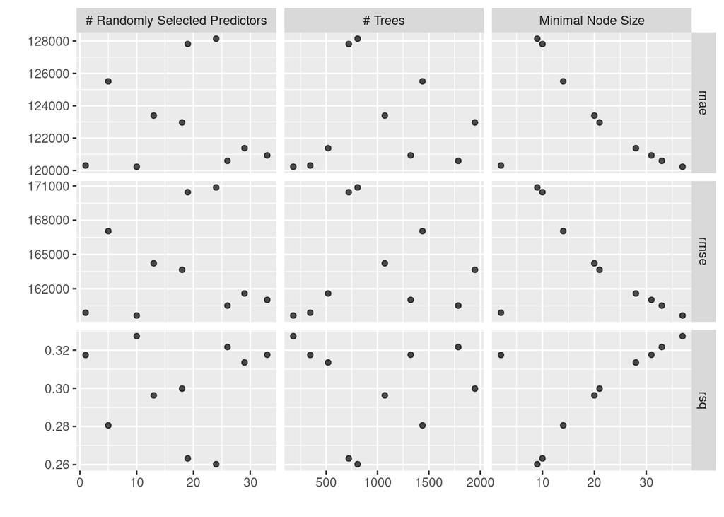

```
## # A tibble: 3 × 4
##   .metric .estimator  .estimate .config
##   <chr>   <chr>           <dbl> <chr>
## 1 rsq     standard        0.267 Preprocessor1_Model1
## 2 rmse    standard   161220.    Preprocessor1_Model1
## 3 mae     standard   124196.    Preprocessor1_Model1
```

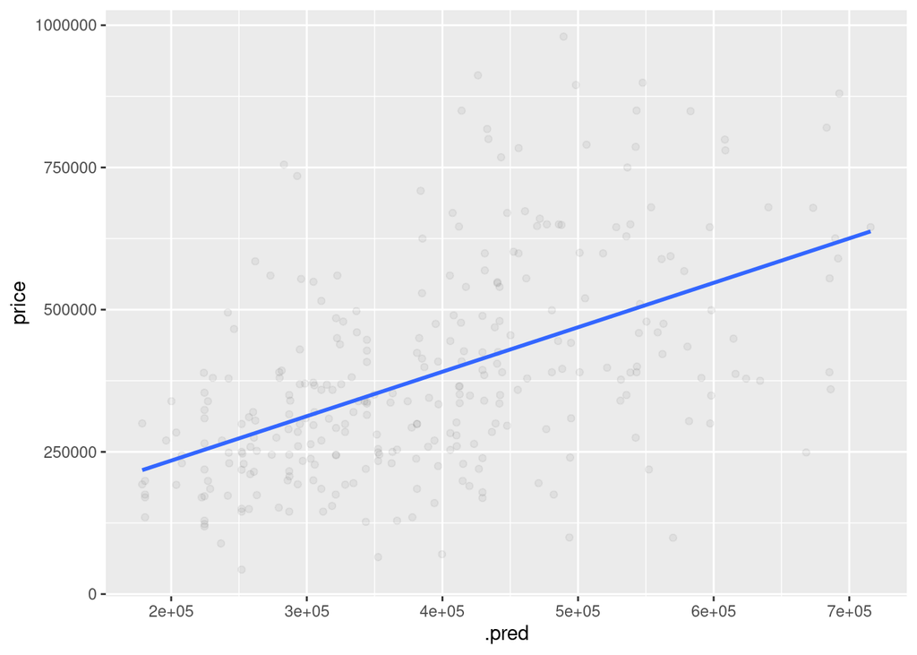

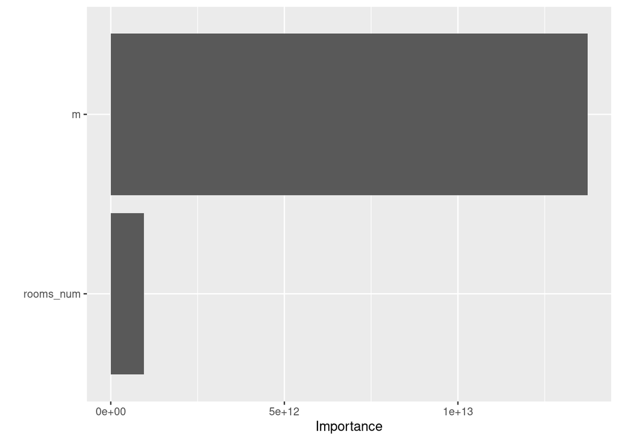